# Review Analysis Tests: Review Count & Review Length

Eugenie

12/08/2019

# 1 Load Source File

Data pre-processing is included, where special chars and minimal stop-words are removed.

```r
library(data.table)
## load review data
source("~/Dropbox/Eugenie/scripts/utils.R")
```

Load AWS review sentiment data.

# 2 Data Processing

Add category data as extra columns. Join on either item_id or child_id.

Drop records before 2012.

Drop records after 2018-10-07 since it’s not a full week.

Drop records with no product category.

Get selected columns for further analysis.

# 3 Analysis Test: Daily Average Review Count

## 3.1 Data Processing

First, we estimate the number of days the product has been available for review by counting the number of days from the first review to the last review.

Get the daily number of reviews per item.

Get mean, variance, and standard deviation of the number of reviews per day by item.

Get the number of daily reviews that is 3 sd’s away.

Get the item_id and days where the number of daily reviews is above the threshold.

Join results with initial data frame.

## 3.2 Result Analysis

### 3.2.1 Overview Stats

| after_ban | review_count.test | Freq | Freq_pct |
| --- | --- | --- | --- |
| before | pass | 56615 | 93.122903 |
| before | fail | 4181 | 6.877097 |
| after | pass | 167691 | 94.023549 |
| after | fail | 10659 | 5.976451 |

The percentage of reviews on suspicious days is a bit lower than it was prior to 2016-10-03.

How many of them are incentivized?

| incentivized | review_count.test | Freq | Freq_pct |
| --- | --- | --- | --- |
| non-incentivized | pass | 222546 | 93.770699 |
| non-incentivized | fail | 14784 | 6.229301 |
| incentivized | pass | 1760 | 96.916300 |
| incentivized | fail | 56 | 3.083700 |

Mean review rating for over vs. under daily threshold for the number of reviews.

| Group.1 | x |
| --- | --- |
| pass | 4.289702 |
| fail | 4.467183 |

Review distribution between groups.

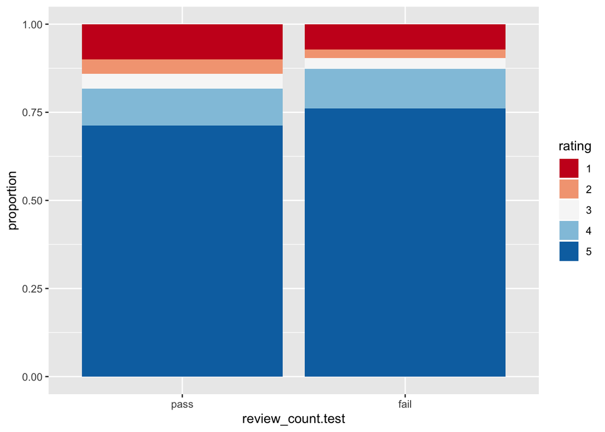

Percentage of reviews that is over daily threshold by item.

```
##     Min.  1st Qu.   Median     Mean  3rd Qu.     Max.
##   0.5405   4.2212   7.8553  13.0080  14.9894 100.0000
```

### 3.2.2 Linear Regression with Fixed Effect on Item ID

**Linear Regression with Fixed Effect: Daily Review Count**

|  | *Dependent variable:* |
| --- | --- |
|  | rating |
| review_count.testfail | 0.164*** |
|  | (0.011) |
| Observations | 239,146 |
| R<sup>2</sup> | 0.001 |
| Adjusted R<sup>2</sup> | 0.0005 |
| F Statistic | 218.918*** (df = 1; 239045) |
| *Note:* | p<0.1; p<0.05; p<0.01 |

From the result of the linear fixed effect modelling, the null hypothesis of the independency of products is rejected.

# 4 Analysis Test: Average Review Length

Once we have the word count distribution of the product and the expected distribution of the category we compare the two distributions and identify product word count groups that are higher in concentration than we’d expect to see.

## 4.1 Data Processing

Bin the review length.

Get the length of reviews per product category.

By product category, calculate mean, variance, and standard deviation.

Get the number of daily reviews that is 2 sd’s away.

Get the item_id and days where the number of daily reviews is above the threshold.

Join results with initial data frame.

## 4.2 Result Analysis

### 4.2.1 Overview Stats

| after_ban | word_count.test | Freq | Freq_pct |
| --- | --- | --- | --- |
| before | pass | 56489 | 92.915652 |
| before | fail | 4307 | 7.084348 |
| after | pass | 174284 | 97.720213 |
| after | fail | 4066 | 2.279787 |

How many of them are incentivized?

| incentivized | word_count.test | Freq | Freq_pct |
| --- | --- | --- | --- |
| non-incentivized | pass | 229390 | 96.654447 |
| non-incentivized | fail | 7940 | 3.345553 |
| incentivized | pass | 1383 | 76.156388 |
| incentivized | fail | 433 | 23.843612 |

Mean review rating for over vs. under length threshold for the number of reviews.

| Group.1 | x |
| --- | --- |
| pass | 4.291117 |
| fail | 4.565269 |

Review distribution between groups.

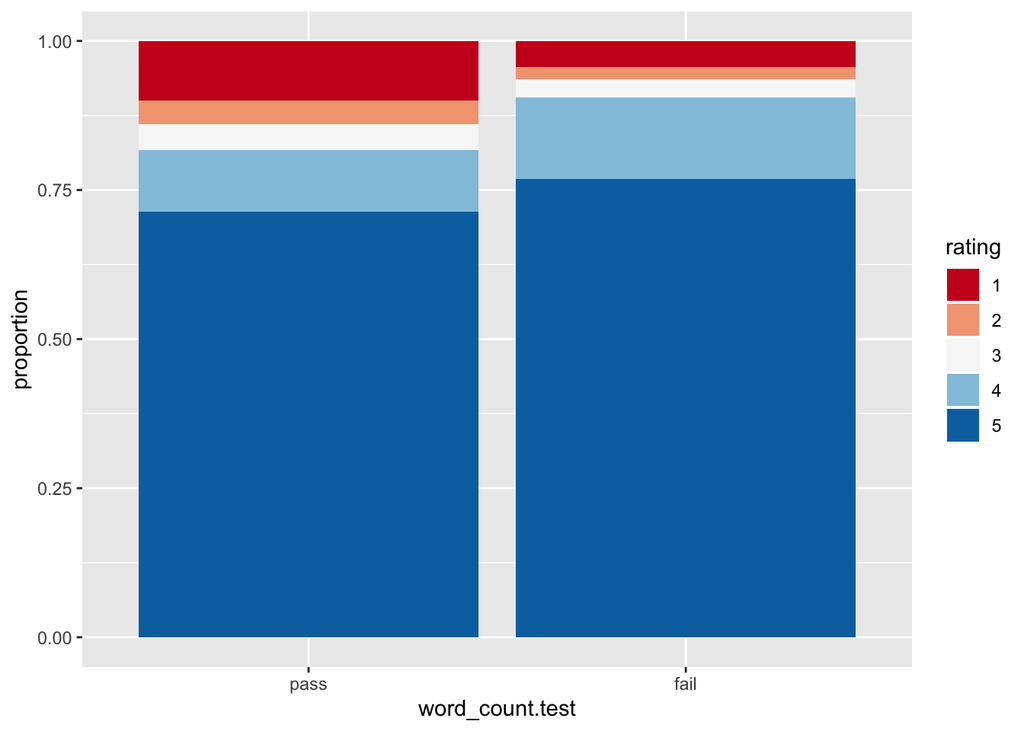

Percentage of reviews that is over length threshold by item.

```
##    Min. 1st Qu.  Median    Mean 3rd Qu.    Max.
##   0.000   0.000   0.000   3.454   0.000  63.330
```

### 4.2.2 Linear Regression with Fixed Effect on Item ID

**Linear Regression with Fixed Effect: Review Word Count**

|  | *Dependent variable:* |
| --- | --- |
|  | rating |
| word_count.testfail | 0.283*** |
|  | (0.019) |
| Observations | 239,146 |
| R<sup>2</sup> | 0.001 |
| Adjusted R<sup>2</sup> | 0.0005 |
| F Statistic | 212.846*** (df = 1; 239045) |
| *Note:* | p<0.1; p<0.05; p<0.01 |

From the result of the linear fixed effect modelling, the null hypothesis of the independency of products is rejected.

### 4.2.3 Graphs

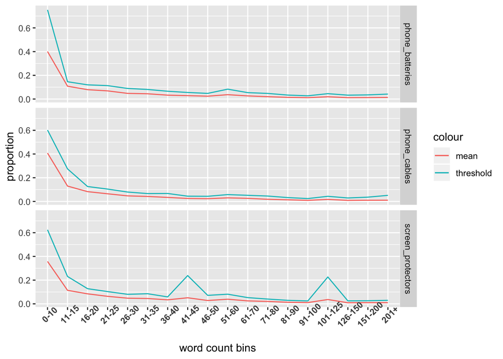

# 5 Analysis on Reviews Fail Both Tests

## 5.1 The number/percentage of reviews fail both/single test(s)

| .id | review_count.test | word_count.test | Freq | Freq_pct |
| --- | --- | --- | --- | --- |
| NA | pass | pass | 216659 | 90.5969575 |
| NA | fail | pass | 14114 | 5.9018340 |
| NA | pass | fail | 7647 | 3.1976282 |
| NA | fail | fail | 726 | 0.3035802 |

## 5.2 After the ban date

| after_ban | review_count.test | word_count.test | Freq | Freq_pct |
| --- | --- | --- | --- | --- |
| before | pass | pass | 52872 | 86.9662478 |
| before | fail | pass | 3617 | 5.9494046 |
| before | pass | fail | 3743 | 6.1566550 |
| before | fail | fail | 564 | 0.9276926 |
| after | pass | pass | 163787 | 91.8345949 |
| after | fail | pass | 10497 | 5.8856182 |
| after | pass | fail | 3904 | 2.1889543 |
| after | fail | fail | 162 | 0.0908326 |

## 5.3 How many are incentivized?

| incentivized | review_count.test | word_count.test | Freq | Freq_pct |
| --- | --- | --- | --- | --- |
| non-incentivized | pass | pass | 215319 | 90.7255720 |
| non-incentivized | fail | pass | 14071 | 5.9288754 |
| non-incentivized | pass | fail | 7227 | 3.0451270 |
| non-incentivized | fail | fail | 713 | 0.3004256 |
| incentivized | pass | pass | 1340 | 73.7885463 |
| incentivized | fail | pass | 43 | 2.3678414 |
| incentivized | pass | fail | 420 | 23.1277533 |
| incentivized | fail | fail | 13 | 0.7158590 |

## 5.4 Focus on one product and see if further analysis could be potentially interesting

### 5.4.1 Distribution of word count bins

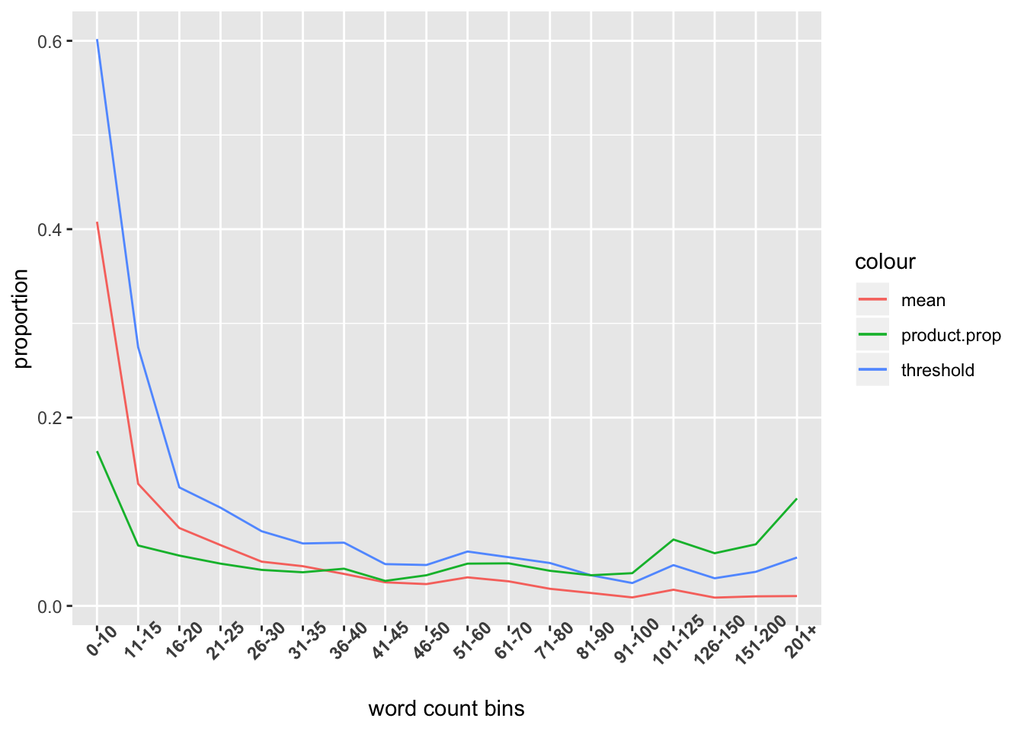

From the graph, groups with larger number of word counts get overpresented. When I dig into the reviews of this particular product, I thought the shorter reviews tend to fail the daily review count test. But, the actual percentage of the reviews failing the review count test is consistent across word count groups.

```r
temp <- data.frame(table(reviews.product[,c('word_count.binned','review_count.test')]))
knitr::kable(ddply(temp, .(word_count.binned), mutate, Freq_pct = Freq/sum(Freq)*100))
```

| word_count.binned | review_count.test | Freq | Freq_pct |
| --- | --- | --- | --- |
| 0-10 | pass | 83326 | 93.439939 |
| 0-10 | fail | 5850 | 6.560061 |
| 11-15 | pass | 24715 | 93.848491 |
| 11-15 | fail | 1620 | 6.151509 |
| 16-20 | pass | 18919 | 93.820977 |
| 16-20 | fail | 1246 | 6.179023 |
| 21-25 | pass | 15422 | 94.237702 |
| 21-25 | fail | 943 | 5.762298 |
| 26-30 | pass | 12012 | 94.071580 |
| 26-30 | fail | 757 | 5.928420 |
| 31-35 | pass | 10046 | 94.107728 |
| 31-35 | fail | 629 | 5.892272 |
| 36-40 | pass | 8352 | 94.394213 |
| 36-40 | fail | 496 | 5.605787 |
| 41-45 | pass | 6713 | 94.349965 |
| 41-45 | fail | 402 | 5.650035 |
| 46-50 | pass | 5667 | 94.292845 |
| 46-50 | fail | 343 | 5.707155 |
| 51-60 | pass | 8896 | 94.417321 |
| 51-60 | fail | 526 | 5.582679 |
| 61-70 | pass | 6458 | 93.662074 |
| 61-70 | fail | 437 | 6.337926 |
| 71-80 | pass | 4658 | 93.646964 |
| 71-80 | fail | 316 | 6.353036 |
| 81-90 | pass | 3560 | 93.980993 |
| 81-90 | fail | 228 | 6.019007 |
| 91-100 | pass | 2745 | 93.942505 |
| 91-100 | fail | 177 | 6.057495 |
| 101-125 | pass | 4572 | 93.746155 |
| 101-125 | fail | 305 | 6.253845 |
| 126-150 | pass | 2612 | 94.024478 |
| 126-150 | fail | 166 | 5.975522 |
| 151-200 | pass | 2672 | 93.820225 |
| 151-200 | fail | 176 | 6.179775 |
| 201+ | pass | 2961 | 92.996231 |
| 201+ | fail | 223 | 7.003769 |

Data processing for further analysis.

### 5.4.2 Linear regression test on the result of two tests separately

**Linear Regression: Daily Review Count & Word Count Overpresented Groups**

|  | *Dependent variable:* |
| --- | --- |
|  | rating |
| word_count.testfail | -0.003 |
|  | (0.029) |
| review_count.testfail | 0.204*** |
|  | (0.031) |
| Constant | 4.557*** |
|  | (0.019) |
| Observations | 3,164 |
| R<sup>2</sup> | 0.014 |
| Adjusted R<sup>2</sup> | 0.013 |
| F Statistic | 22.048*** (df = 2; 3161) |
| *Note:* | p<0.1; p<0.05; p<0.01 |

### 5.4.3 Linear regression test to check if the rating differs significantly between reviews that pass both tests and reviews fail either

**Linear Regression: Reviews Fail Either Test**

|  | *Dependent variable:* |
| --- | --- |
|  | rating |
| fail_eitheryes | 0.204*** |
|  | (0.031) |
| Constant | 4.556*** |
|  | (0.017) |
| Observations | 3,164 |
| R<sup>2</sup> | 0.014 |
| Adjusted R<sup>2</sup> | 0.013 |
| F Statistic | 44.103*** (df = 1; 3162) |
| *Note:* | p<0.1; p<0.05; p<0.01 |

Suggest that the two tests are capturing different aspects. They don’t necessarily overlap.

# 6 Other Info

Show products with first reviews after the ban date.

| item_id | first_review.date | last_review.date |
| --- | --- | --- |
| B07HTRWF9S | 2018-10-02 | 2018-10-03 |
| B07HL5X9ZD | 2018-09-26 | 2018-10-01 |
| B07HGCVXRT | 2018-09-17 | 2018-09-21 |
| B07DLTPKHD | 2018-06-24 | 2018-08-01 |
| B07BN5S3Q3 | 2018-04-16 | 2018-08-14 |
| B07793KSV4 | 2017-12-11 | 2018-07-27 |
| B01A2W5EBA | 2017-01-04 | 2018-05-23 |
| B01MZYYXVK | 2016-12-31 | 2018-09-22 |
| B07G3TXVN7 | 2016-12-27 | 2018-10-02 |
| B06VSP8PXH | 2016-12-14 | 2018-10-06 |
| B01MAU9IJS | 2016-11-17 | 2018-09-07 |
| B01KL1AIDG | 2016-10-27 | 2018-10-01 |
| B00Z7SKQSQ | 2016-10-22 | 2018-05-22 |
| B01LXZDPDR | 2016-10-17 | 2018-07-15 |
| B01M0WUEWU | 2016-10-13 | 2018-08-10 |
| B078XDLDNM | 2016-10-09 | 2018-07-14 |
| B01MFGDAC8 | 2016-10-04 | 2018-09-25 |
| B01LA941IG | 2016-10-03 | 2018-09-30 |

Percentage/count of reviews for products didn’t come out until 2016-10-03 (after ban date).

| .id | Var1 | Freq | Freq_pct |
| --- | --- | --- | --- |
| NA | before | 217257 | 90.847014 |
| NA | after | 21889 | 9.152986 |